This is my MT5000 Quarto Assignment Solution

# Prepare libraries and processes

```r
library(maps)

library(tidyverse)
library(gapminder)

options("scipen" = 999)
```

# Reading the files

## The data used in this assignment is provided by UNICEF and the analysis will only serve the purpose of complete the requirment of assignment

```r
unicef_ind_df1 <- read.csv("./unicef_indicator_1.csv")

unicef_ind_df2 <- read.csv("./unicef_indicator_2.csv")

unicef_metadata <- read.csv("./unicef_metadata.csv")

str(gapminder)
```

```
## tibble [1,704 × 6] (S3: tbl_df/tbl/data.frame)
##  $ country  : Factor w/ 142 levels "Afghanistan",..: 1 1 1 1 1 1 1 1 1 1 ...
##  $ continent: Factor w/ 5 levels "Africa","Americas",..: 3 3 3 3 3 3 3 3 3 3 ...
##  $ year     : int [1:1704] 1952 1957 1962 1967 1972 1977 1982 1987 1992 1997 ...
##  $ lifeExp  : num [1:1704] 28.8 30.3 32 34 36.1 ...
##  $ pop      : int [1:1704] 8425333 9240934 10267083 11537966 13079460 14880372 12881816 13867957 16317921 22227415 ...
##  $ gdpPercap: num [1:1704] 779 821 853 836 740 ...
```

# Data transformation

### In order to make the data clear for efficient visualisation, I would like to make some calculations base on the original data including the change of the life expectancy (life-gap) by using the life expectancy 2020 to substract the one of 2020.

```r
map_world <- map_data("world")

pop_2020 <- unicef_metadata %>%
  filter(year==2020)

pop_2000 <- unicef_metadata %>%
  filter(year==2000)

map_pop_2000 <- full_join(map_world, pop_2000, by = c("region" = "country"))

map_pop_2020 <- full_join(map_world, pop_2020, by = c("region" = "country"))

pop_2020['Life.expectancy.at.birth..total..years.2000'] <-pop_2000['Life.expectancy.at.birth..total..years.']

pop_2020['Life.expectancy.gap'] <-pop_2020['Life.expectancy.at.birth..total..years.']-pop_2020['Life.expectancy.at.birth..total..years.2000']

new_sorted_pop_2020 <- pop_2020[order(pop_2020['Life.expectancy.gap']),]
new_sorted_pop_2020 <- new_sorted_pop_2020 %>% drop_na('Life.expectancy.gap')

new_0_pop_2020 <- new_sorted_pop_2020%>%filter(Life.expectancy.gap < 0 )

countries_life_0 <- (new_0_pop_2020['country'])

countries_life_0
```

```
##                             country
## 1                            Mexico
## 2 Venezuela, Bolivarian Republic of
## 3                         Venezuela
## 4                           Ecuador
```

```r
rows_mexico <- unicef_metadata %>% filter(country =='Mexico')
```

# Visualize world map chart

### After getting the result from calculation, I put it into the map and The world map which showed the change in life expectancy around the world between 2000 and 2020. The chart pointed out that Mexican ranked 1st which mark the biggest decrease in life expectancy in those 20 years

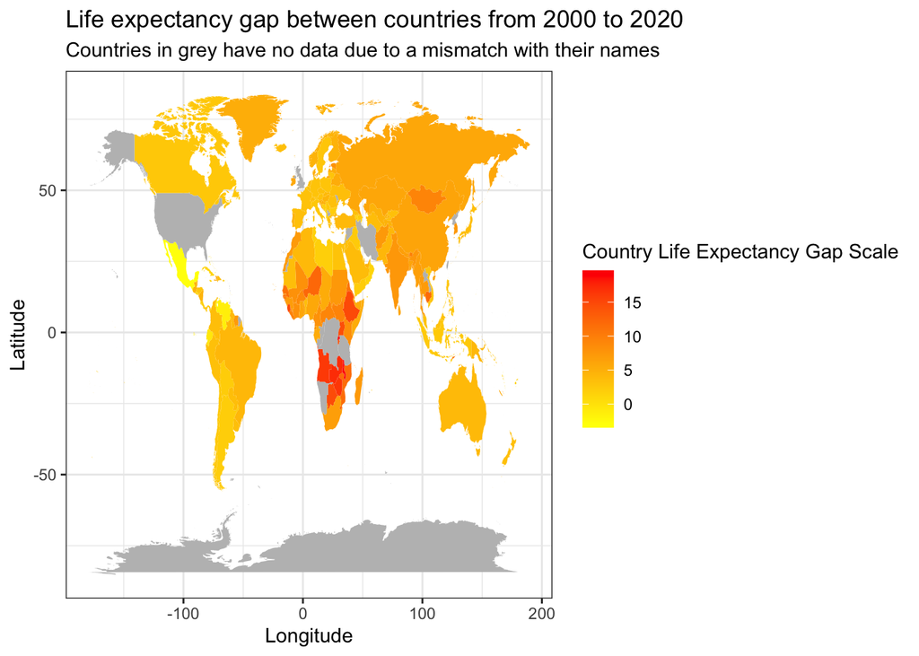

```r
map_sorted_2020 <- full_join(map_world,new_sorted_pop_2020,by=c('region'='country'))

ggplot(data = map_sorted_2020) +
  aes(x = long, y = lat, group = group, fill=Life.expectancy.gap) +
  geom_polygon() +
  scale_fill_gradient(low = "yellow", high = "red", na.value = "grey") +
  labs(
    title = "Life expectancy gap between countries from 2000 to 2020",
    subtitle = "Countries in grey have no data due to a mismatch with their names",
    x = "Longitude",
    y = "Latitude",
    fill = "Country Life Expectancy Gap Scale"
  ) +
  theme_bw()
```